# Cottonwood Creek

Sadie Gill, Mark Tompkins

July 2020

## Future Data Improvements

None planned.

## Instream Spawning and Rearing Habitat

**Data Source:** [CDFW 1979](https://s3-us-west-2.amazonaws.com/cvpiahabitat-r-package/cvpia-sit-model-inputs/CDFW1979_CottonwoodSpawningIFIM.PDF) (pgs 11-15) and [UFWS 2013](https://cvpiahabitat-r-package.s3-us-west-2.amazonaws.com/cvpia-sit-model-inputs/CVPIA_Annual_Progress_Report_Fiscal_Year_2013.pdf) (pgs 46-47)

### Spawning and Rearing Data

The instream spawning and rearing habitat data described above for Fall Run Chinook Salmon (FR) is combined for use in the Decision Support Model (DSM) in the following format. Units are in square feet per 1000 feet.

Header Descriptions: flow_cfs = flow in cubic feet per second, FR_spawn_wua = Fall Run Chinook Spawning WUA, FR_fry_wua = Fall Run Chinook Fry WUA, FR_juv_wua = Fall Run Chinook Juvenile WUA, ST_fry_wua = Steelhead Fry WUA, ST_juv_wua = Steelhead Juvenile WUA, watershed = section of stream modeled for CVPIA SDM

[output not shown]

*… with 21 more rows*

### Spawning WUA

The following plot shows the weighted usable spawning area (WUA) in square feet per thousand feet for Fall Run Chinook Salmon. These area per length rates are multiplied by the total spawning reach length mapped by the Science Integration Team (SIT) to estimate available habitat.

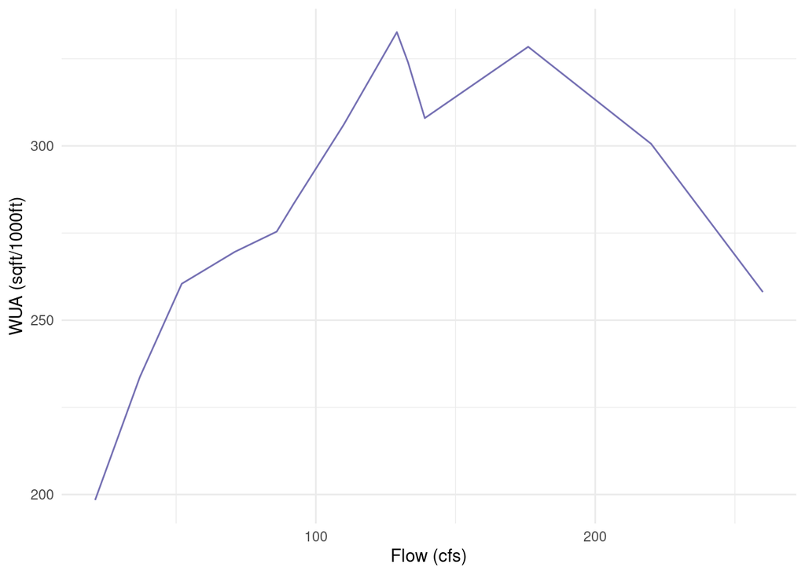

### Rearing WUA

The following plot shows the rearing WUA in square feet per thousand feet for Fall Run Chinook Salmon and Steelhead fry and juvenile. These rates are multiplied by the total rearing reach length mapped by the SIT to estimate available habitat.

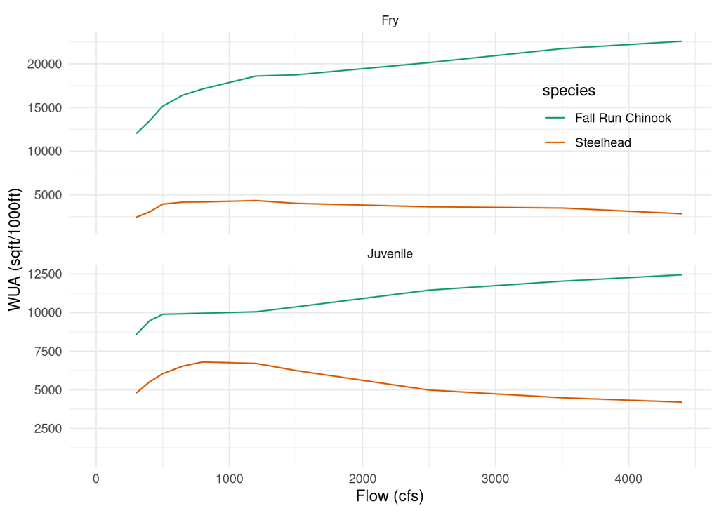

## Floodplain Rearing Habitat

**Data Source:** [USFWS / FEMA 1D HEC-RAS hydraulic model](https://s3-us-west-2.amazonaws.com/cvpiahabitat-r-package/cvpia-sit-model-inputs/CVPIA+Annual+Progress+Report+Fiscal+Year+2017.pdf)

### Fall Run

A 22.4 mile portion of the entire mapped rearing extent of 22.4 miles was modeled using USFWS / FEMA 1D HEC-RAS hydraulic model. Of the entire mapped rearing extent, 22.4 miles were classified as low gradient and 0 miles were classified as high gradient based on a geomorphic analysis of long profile slopes and valley widths. The floodplain area per unit length was determined for the modeled extent and used to approximate areas for the non-modeled extent. The area per unit length was scaled by a factor of 0.1 for the high gradient extent. There was no scaling factor applied to the low gradient extent.

### Spring Run

A 22.4 mile portion of the entire mapped rearing extent of 119.5 miles was modeled using USFWS / FEMA 1D HEC-RAS hydraulic model. Of the entire mapped rearing extent, 22.4 miles were classified as low gradient and 97.1 miles were classified as high gradient based on a geomorphic analysis of long profile slopes and valley widths. The floodplain area per unit length was determined for the modeled extent and used to approximate areas for the non-modeled extent. The area per unit length was scaled by a factor of 0.1 for the high gradient extent. There was no scaling factor applied to the low gradient extent.

### Steelhead

A 22.4 mile portion of the entire mapped rearing extent of 142.3 miles was modeled using USFWS / FEMA 1D HEC-RAS hydraulic model. Of the entire mapped rearing extent, 22.4 miles were classified as low gradient and 119.9 miles were classified as high gradient based on a geomorphic analysis of long profile slopes and valley widths. The floodplain area per unit length was determined for the modeled extent and used to approximate areas for the non-modeled extent. The area per unit length was scaled by a factor of 0.1 for the high gradient extent. There was no scaling factor applied to the low gradient extent.

## Floodplain Data

The areas represent total inundated area in acres.

Header Descriptions: flow_cfs = flow in cubic feet per second, FR_floodplain_acres = Fall Run Chinook floodplain acres, SR_floodplain_acres = Spring Run Chinook floodplain acres, ST_floodplain_acres = Steelhead floodplain acres, watershed = section of stream modeled for CVPIA SDM

| flow_cfs | FR_floodplain_acres | SR_floodplain_acres | ST_floodplain_acres | watershed |
| --- | --- | --- | --- | --- |
| 40 | 0.00 | 0.00 | 0.00 | Cottonwood Creek |
| 400 | 7.81 | 11.21 | 12.01 | Cottonwood Creek |
| 760 | 13.46 | 19.31 | 20.68 | Cottonwood Creek |
| 1120 | 21.57 | 30.94 | 33.14 | Cottonwood Creek |
| 1480 | 28.45 | 40.81 | 43.71 | Cottonwood Creek |

## Floodplain Plot

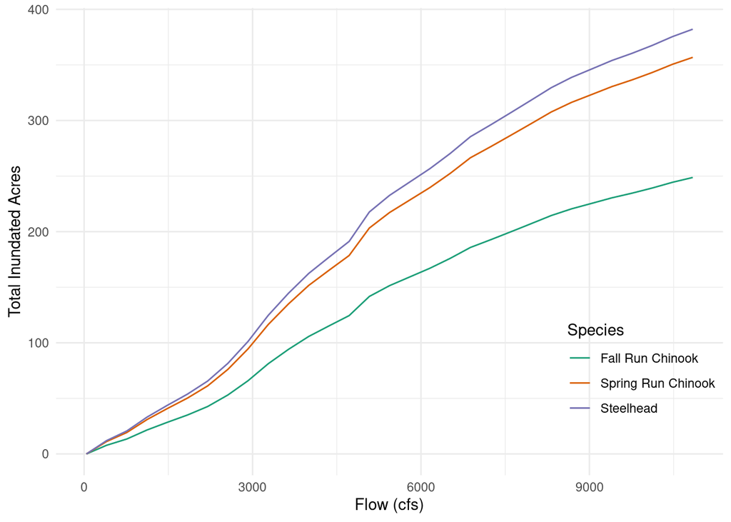